# Statistical Learning - Data preparation & Supervised Learning

Angelina Khatiwada, Rijin Baby

09/06/2021

## Data Set Information:

This data was collected via a survey on Amazon Mechanical Turk. The survey describes different driving scenarios including the destination, current time, weather, passenger, etc., and then ask the person whether he will accept the coupon if he is the driver.

## Some Attribute Information:

- expiration: 1d, 2h (the coupon expires in 1 day or in 2 hours)
- Bar: never, less1, 1~3, gt8, nan4~8 (feature meaning: how many times do you go to a bar every month?)
- CoffeeHouse: never, less1, 4~8, 1~3, gt8, nan (feature meaning: how many times do you go to a coffeehouse every month?)
- CarryAway:n4~8, 1~3, gt8, less1, never (feature meaning: how many times do you get take-away food every month?)
- RestaurantLessThan20: 4~8, 1~3, less1, gt8, never (feature meaning: how many times do you go to a restaurant with an average expense per person of less than $20 every month?)
- Restaurant20To50: 1~3, less1, never, gt8, 4~8, nan (feature meaning: how many times do you go to a restaurant with average expense per person of $20 - $50 every month?)
- toCoupon_GEQ15min:0,1 (feature meaning: driving distance to the restaurant/bar for using the coupon is greater than 15 minutes)
- toCoupon_GEQ25min:0, 1 (feature meaning: driving distance to the restaurant/bar for using the coupon is greater than 25 minutes)
- direction_same:0, 1 (feature meaning: whether the restaurant/bar is in the same direction as your current destination)
- direction_opp:1, 0 (feature meaning: whether the restaurant/bar is in the same direction as your current destination)
- Y:1, 0 (whether the coupon is accepted)

```r
    library(skimr)
    library(readr)
    library(plyr)
    library(dplyr)
    library(purrr)
    library(VIM)
    library(ggplot2)
    library(plotly)
    library(caret)
    library(grid)
    library(gridExtra)
    library("epitools")
    library(pROC)
    library(MASS)
    library(class)
    library(gmodels)
```

## Dataset

```r
  in_vehicle_coupon_recommendation <- read_csv("https://raw.githubusercontent.com/rijinbaby/Statistical-Learning/main/in-vehicle-coupon-recommendation.csv")
  coupon_data <- in_vehicle_coupon_recommendation
  coupon_data <- as.data.frame(coupon_data)

  library(purrr)
  # View(coupon_data %>% map(table))
  coupon_data %>% map(table)
```

```
## $destination
##
##            Home No Urgent Place            Work
##            3237            6283            3164
##
## $passanger
##
##     Alone Friend(s)    Kid(s)   Partner
##      7305      3298      1006      1075
##
## $weather
##
## Rainy Snowy Sunny
##  1210  1405 10069
##
## $temperature
##
##   30   55   80
## 2316 3840 6528
##
## $time
##
## 10AM 10PM  2PM  6PM  7AM
## 2275 2006 2009 3230 3164
##
## $coupon
##
##                   Bar Carry out & Take away          Coffee House
##                  2017                  2393                  3996
##       Restaurant(<20)     Restaurant(20-50)
##                  2786                  1492
##
## $expiration
##
##   1d   2h
## 7091 5593
##
## $gender
##
## Female   Male
```

[output cut: 132 more lines]

```
##
## $direction_same
##
##    0    1
## 9960 2724
##
## $direction_opp
##
##    0    1
## 2724 9960
##
## $Y
##
##    0    1
## 5474 7210
```

### Missing & unique value check

```r
  (colMeans(is.na(coupon_data))*100)
```

```
##          destination            passanger              weather
##            0.0000000            0.0000000            0.0000000
##          temperature                 time               coupon
##            0.0000000            0.0000000            0.0000000
##           expiration               gender                  age
##            0.0000000            0.0000000            0.0000000
##        maritalStatus         has_children            education
##            0.0000000            0.0000000            0.0000000
##           occupation               income                  car
##            0.0000000            0.0000000          100.0000000
##                  Bar          CoffeeHouse            CarryAway
##            0.8435825            1.7108168            1.1904762
## RestaurantLessThan20     Restaurant20To50     toCoupon_GEQ5min
##            1.0249133            1.4900662            0.0000000
##    toCoupon_GEQ15min    toCoupon_GEQ25min       direction_same
##            0.0000000            0.0000000            0.0000000
##        direction_opp                    Y
##            0.0000000            0.0000000
```

```r
  coupon_data$car <- NULL # no data at all - 4 other with <2% missing

  which(apply(coupon_data, 2, function(x) length(unique(x)))==1)
```

```
## toCoupon_GEQ5min
##               20
```

```r
  coupon_data$toCoupon_GEQ5min <- NULL # removing column with single value
```

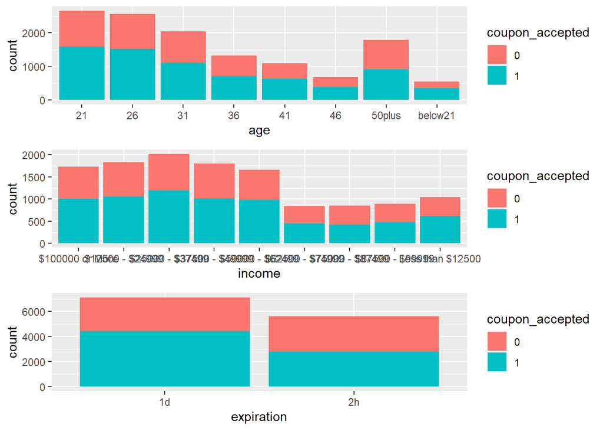

```r
coupon_accepted <- as.factor(coupon_data$Y)

#age
t1 <- ggplot(coupon_data, aes(x=age, fill=coupon_accepted)) +
    geom_bar(stat="count")

#income
t2 <- ggplot(coupon_data, aes(x=income, fill=coupon_accepted)) +
  geom_bar(stat="count")

#expiration
t3 <- ggplot(coupon_data, aes(x=expiration, fill=coupon_accepted)) +
  geom_bar(stat="count")

grid.arrange(t1, t2, t3, ncol=1)
```

### New Variables

```r
{
  coupon_data[] <- lapply(coupon_data, as.character)
  coupon_data$Y <- as.numeric(coupon_data$Y)

  # age column - Creating a new column to give numerical weightage
  table(coupon_data$age)
  coupon_data$age_weightage <- NA
  coupon_data$age_weightage[which(coupon_data$age=="below21")] <- 1
  coupon_data$age_weightage[which(coupon_data$age=="21")] <- 2
  coupon_data$age_weightage[which(coupon_data$age=="26")] <- 3
  coupon_data$age_weightage[which(coupon_data$age=="31")] <- 4
  coupon_data$age_weightage[which(coupon_data$age=="36")] <- 5
  coupon_data$age_weightage[which(coupon_data$age=="41")] <- 6
  coupon_data$age_weightage[which(coupon_data$age=="46")] <- 7
  coupon_data$age_weightage[which(coupon_data$age=="50plus")] <- 8
  table(coupon_data$age_weightage)

  # temp & weather
  # View(table(coupon_data$weather,coupon_data$temperature))

  # Income - Creating a new column to give numerical weightage
  table(coupon_data$income)
  coupon_data$income_weightage <- NA
  coupon_data$income_weightage[which(coupon_data$income=="Less than $12500")] <- 1
  coupon_data$income_weightage[which(coupon_data$income=="$12500 - $24999")] <- 2
  coupon_data$income_weightage[which(coupon_data$income=="$25000 - $37499")] <- 3
  coupon_data$income_weightage[which(coupon_data$income=="$37500 - $49999")] <- 4
  coupon_data$income_weightage[which(coupon_data$income=="$50000 - $62499")] <- 5
  coupon_data$income_weightage[which(coupon_data$income=="$62500 - $74999")] <- 6
  coupon_data$income_weightage[which(coupon_data$income=="$75000 - $87499")] <- 7
  coupon_data$income_weightage[which(coupon_data$income=="$87500 - $99999")] <- 8
  coupon_data$income_weightage[which(coupon_data$income=="$100000 or More")] <- 9
  table(coupon_data$income_weightage)

  # Income - Creating a new column to re-classify reference - https://en.wikipedia.org/wiki/International_Standard_Classification_of_Occupations
  (table(coupon_data$occupation))
  coupon_data$occupation_class <- NA
  coupon_data$occupation_class[which(coupon_data$occupation %in%
                                       c("Architecture & Engineering","Arts Design Entertainment Sports & Media"
                                         ,"Business & Financial","Computer & Mathematical","Education&Training&Library"
                                         ,"Healthcare Practitioners & Technical","Legal","Management"))] <- "Professionals"
  coupon_data$occupation_class[which(coupon_data$occupation %in%
                                       c("Building & Grounds Cleaning & Maintenance","Food Preparation & Serving Related"
                                         ,"Installation Maintenance & Repair","Transportation & Material Moving"))]  <- "Craft and related trades workers"
  coupon_data$occupation_class[which(coupon_data$occupation %in%
                                       c("Community & Social Services","Construction & Extraction","Healthcare Support"
                                         ,"Life Physical Social Science"))] <- "Technicians and pro"
  coupon_data$occupation_class[which(coupon_data$occupation %in%
                                       c("Personal Care & Service","Protective Service","Sales & Related"))] <- "Service and sales"
  coupon_data$occupation_class[which(coupon_data$occupation %in%
                                       c("Farming Fishing & Forestry","Office & Administrative Support"
                                         ,"Production Occupations"))] <- "Others"  #own classification
  coupon_data$occupation_class[which(coupon_data$occupation=="Retired")] <- 'Retired'
  coupon_data$occupation_class[which(coupon_data$occupation=="Student")] <- "Student"
  coupon_data$occupation_class[which(coupon_data$occupation=="Unemployed")] <- "Unemployed"

  occup_class <- coupon_data %>%
  group_by(occupation_class) %>%
  summarise("Actual_occupation" = occupation)
  occup_class <- unique(occup_class)


  # TIME VARIABLE
  table(coupon_data$expiration)
  coupon_data$expiration_weightage <- NA
  coupon_data$expiration_weightage[which(coupon_data$expiration=="2h")] <- 2
  coupon_data$expiration_weightage[which(coupon_data$expiration=="1d")] <- 24

  # passenger
  coupon_data$passanger[which(coupon_data$passanger=="Friend(s)")] <- "Friends"
  coupon_data$passanger[which(coupon_data$passanger=="Kid(s)")] <- "Kids"

  # education
  coupon_data$education[which(coupon_data$education=="Graduate degree (Masters or Doctorate)")] <- "Graduate degree"
  # print(table(coupon_data$occupation_class))

}
```

```r
knitr::kable(occup_class, format = "html")
```

| occupation_class | Actual_occupation |
| --- | --- |
| Craft and related trades workers | Installation Maintenance & Repair |
| Craft and related trades workers | Transportation & Material Moving |
| Craft and related trades workers | Food Preparation & Serving Related |
| Craft and related trades workers | Building & Grounds Cleaning & Maintenance |
| Others | Office & Administrative Support |
| Others | Production Occupations |
| Others | Farming Fishing & Forestry |
| Professionals | Architecture & Engineering |
| Professionals | Education&Training&Library |
| Professionals | Healthcare Practitioners & Technical |
| Professionals | Management |
| Professionals | Arts Design Entertainment Sports & Media |
| Professionals | Computer & Mathematical |
| Professionals | Legal |
| Professionals | Business & Financial |
| Retired | Retired |
| Service and sales | Sales & Related |
| Service and sales | Personal Care & Service |
| Service and sales | Protective Service |
| Student | Student |
| Technicians and pro | Healthcare Support |
| Technicians and pro | Life Physical Social Science |
| Technicians and pro | Community & Social Services |
| Technicians and pro | Construction & Extraction |
| Unemployed | Unemployed |

### missing imputation knn approach

```r
  library(VIM)
  # colMeans(is.na(coupon_data))*100
  # which(colMeans(is.na(coupon_data))>0)
  cleaned_data <- kNN(coupon_data
                           , variable = c("Bar","CoffeeHouse","CarryAway","RestaurantLessThan20","Restaurant20To50")
                           , k = 5)
  cleaned_data <- cleaned_data[,1:ncol(coupon_data)]
  # coupon_data_final %>% map(table)
  colMeans(is.na(cleaned_data))*100
```

```
##          destination            passanger              weather
##                    0                    0                    0
##          temperature                 time               coupon
##                    0                    0                    0
##           expiration               gender                  age
##                    0                    0                    0
##        maritalStatus         has_children            education
##                    0                    0                    0
##           occupation               income                  Bar
##                    0                    0                    0
##          CoffeeHouse            CarryAway RestaurantLessThan20
##                    0                    0                    0
##     Restaurant20To50    toCoupon_GEQ15min    toCoupon_GEQ25min
##                    0                    0                    0
##       direction_same        direction_opp                    Y
##                    0                    0                    0
##        age_weightage     income_weightage     occupation_class
##                    0                    0                    0
## expiration_weightage
##                    0
```

### Plotting data

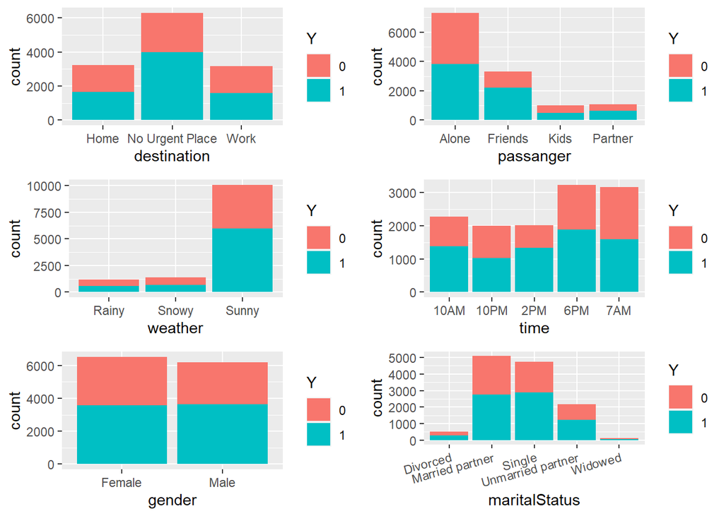

```r
library(gridExtra)
cleaned_data$Y <- as.factor(cleaned_data$Y)

#Destination
p1 <- ggplot(cleaned_data, aes(x=destination, fill=Y)) +
    geom_bar(stat="count")

#passanger
p2 <- ggplot(cleaned_data, aes(x=passanger, fill=Y)) +
  geom_bar(stat="count")

#weather
p3 <- ggplot(cleaned_data, aes(x=weather, fill=Y)) +
  geom_bar(stat="count")

#time
p4 <- ggplot(cleaned_data, aes(x=time, fill=Y)) +
  geom_bar(stat="count")

#gender
p5 <- ggplot(cleaned_data, aes(x=gender, fill=Y)) +
  geom_bar(stat="count")

#maritalStatus
p6 <- ggplot(cleaned_data, aes(x=maritalStatus, fill=Y)) +
  geom_bar(stat="count")+
  theme(axis.text.x = element_text(angle = 15, hjust = 1))

grid.arrange(p1, p2, p3, p4, p5, p6, ncol=2)
```

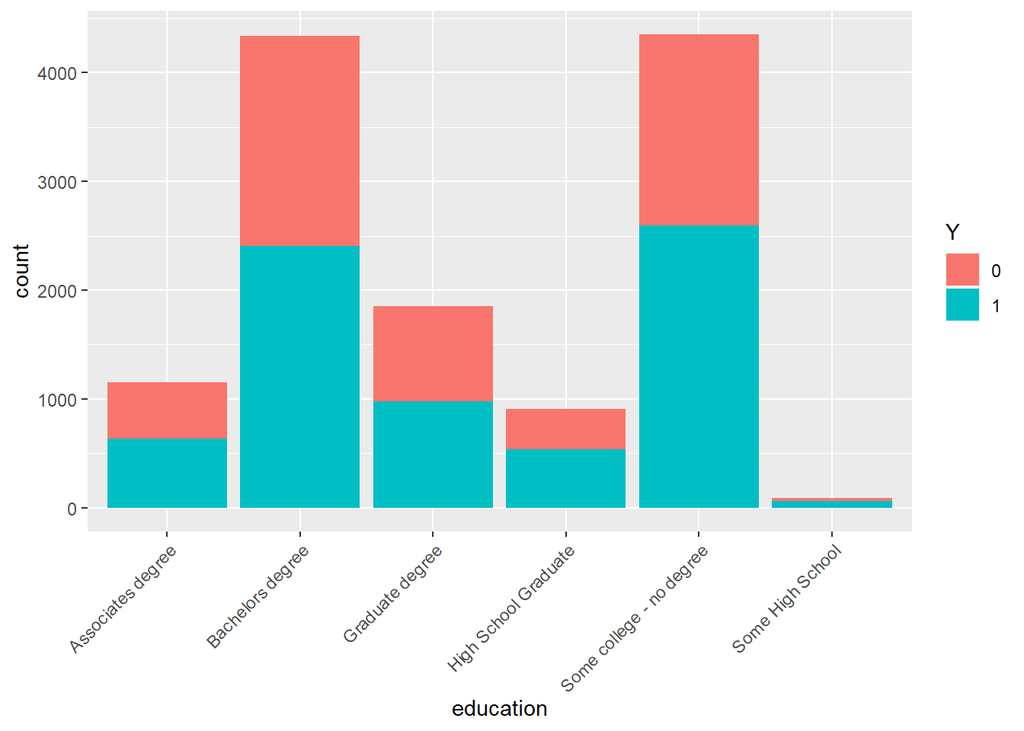

```r
#education
p7 <- ggplot(cleaned_data, aes(x=education, fill=Y)) +
  geom_bar(stat="count")+
  theme(axis.text.x = element_text(angle = 45, hjust = 1))
p7
```

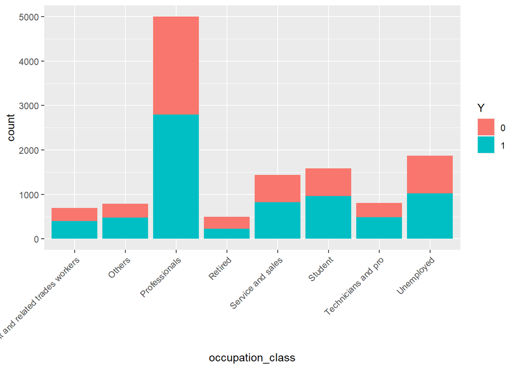

```r
#occupation
p8 <- ggplot(cleaned_data, aes(x=occupation_class, fill=Y)) +
  geom_bar(stat="count")+
  theme(axis.text.x = element_text(angle = 45, hjust = 1))
p8
```

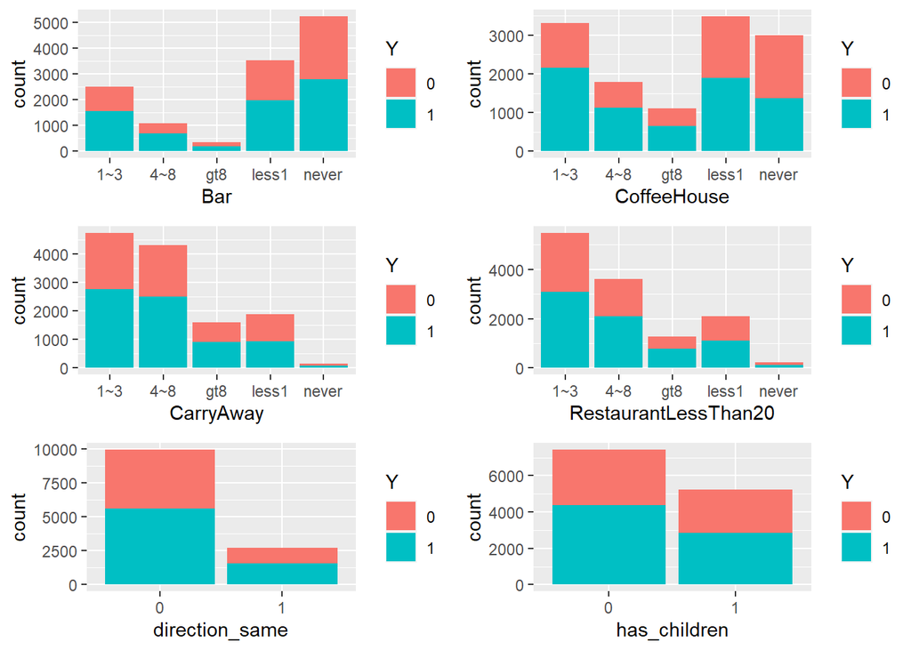

```r
#Bar
p9 <- ggplot(cleaned_data, aes(x=Bar, fill=Y)) +
  geom_bar(stat="count")

#CoffeeHouse
p10 <- ggplot(cleaned_data, aes(x=CoffeeHouse, fill=Y)) +
  geom_bar(stat="count")

#CarryAway
p11 <- ggplot(cleaned_data, aes(x=CarryAway, fill=Y)) +
  geom_bar(stat="count")

#RestaurantLessThan20
p12 <- ggplot(cleaned_data, aes(x=RestaurantLessThan20, fill=Y)) +
  geom_bar(stat="count")

#direction_same
p13 <- ggplot(cleaned_data, aes(x=direction_same, fill=Y)) +
  geom_bar(stat="count")

#has_children
p14 <- ggplot(cleaned_data, aes(x=has_children, fill=Y)) +
  geom_bar(stat="count")

grid.arrange(p9, p10, p11, p12, p13, p14, ncol=2)
```

**For numeric variables**

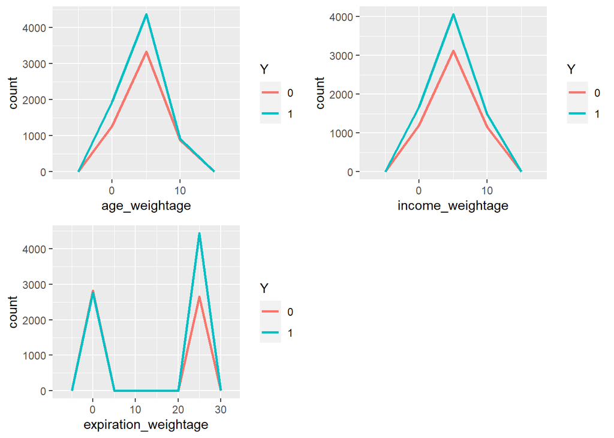

```r
#Age histogram
p15 <- ggplot(data = cleaned_data, aes(age_weightage, color = Y))+
  geom_freqpoly(binwidth = 5, size = 1)

#Income histogram
p16 <- ggplot(data = cleaned_data, aes(income_weightage, color = Y))+
  geom_freqpoly(binwidth = 5, size = 1)

#Expiration histogram
p17 <- ggplot(data = cleaned_data, aes(expiration_weightage, color = Y))+
  geom_freqpoly(binwidth = 5, size = 1)

grid.arrange(p15, p16, p17, ncol=2)
```

## Modeling

We drop the variable ‘direction_opp’ that is perfectly correlated with the varible ‘direction_same’.We also drop the categorical varibles ‘age’, ‘income’, ‘expiration’, for which we created corresponding numeric variables. ‘occupation’ will be replaced by ‘occupation_class’ in the model.

- Y - factor
- ‘age’, ‘income’, ‘expiration’ - numeric
- other variables’ type is characteric, so the dummies will be created automatically, removing the first dummy variable created from each column. This is done to avoid multicollinearity.

```r
drops= c("direction_opp", 'age', 'income', 'expiration', 'occupation') #drop additional correlated variables
cleaned_data <- cleaned_data[ , !(colnames(cleaned_data) %in% drops)]

str(cleaned_data)
```

```
## 'data.frame':    12684 obs. of  23 variables:
##  $ destination         : chr  "No Urgent Place" "No Urgent Place" "No Urgent Place" "No Urgent Place" ...
##  $ passanger           : chr  "Alone" "Friends" "Friends" "Friends" ...
##  $ weather             : chr  "Sunny" "Sunny" "Sunny" "Sunny" ...
##  $ temperature         : chr  "55" "80" "80" "80" ...
##  $ time                : chr  "2PM" "10AM" "10AM" "2PM" ...
##  $ coupon              : chr  "Restaurant(<20)" "Coffee House" "Carry out & Take away" "Coffee House" ...
##  $ gender              : chr  "Female" "Female" "Female" "Female" ...
##  $ maritalStatus       : chr  "Unmarried partner" "Unmarried partner" "Unmarried partner" "Unmarried partner" ...
##  $ has_children        : chr  "1" "1" "1" "1" ...
##  $ education           : chr  "Some college - no degree" "Some college - no degree" "Some college - no degree" "Some college - no degree" ...
##  $ Bar                 : chr  "never" "never" "never" "never" ...
##  $ CoffeeHouse         : chr  "never" "never" "never" "never" ...
##  $ CarryAway           : chr  "1~3" "less1" "less1" "less1" ...
##  $ RestaurantLessThan20: chr  "4~8" "4~8" "4~8" "4~8" ...
##  $ Restaurant20To50    : chr  "1~3" "1~3" "1~3" "1~3" ...
##  $ toCoupon_GEQ15min   : chr  "0" "0" "1" "1" ...
##  $ toCoupon_GEQ25min   : chr  "0" "0" "0" "0" ...
##  $ direction_same      : chr  "0" "0" "0" "0" ...
##  $ Y                   : Factor w/ 2 levels "0","1": 2 1 2 1 1 2 2 2 2 1 ...
##  $ age_weightage       : num  2 2 2 2 2 2 2 2 2 2 ...
##  $ income_weightage    : num  4 4 4 4 4 4 4 4 4 4 ...
##  $ occupation_class    : chr  "Unemployed" "Unemployed" "Unemployed" "Unemployed" ...
##  $ expiration_weightage: num  24 2 2 2 24 2 24 2 2 24 ...
```

## Logistic Regression

**Anova Chi-square test** to check the overall effect of variables on the dependent variable

**Multicollinearity check**

Dataset without splitting

```r
log_model <- glm(Y ~., data = cleaned_data, family=binomial(link='logit'))
summary(log_model)
```

```
##
## Call:
## glm(formula = Y ~ ., family = binomial(link = "logit"), data = cleaned_data)
##
## Deviance Residuals:
##     Min       1Q   Median       3Q      Max
## -2.3909  -1.0284   0.5650   0.9432   2.3961
##
## Coefficients: (1 not defined because of singularities)
##                                      Estimate Std. Error z value Pr(>|z|)
## (Intercept)                         -1.878475   0.247175  -7.600 2.97e-14 ***
## destinationNo Urgent Place           0.807690   0.096807   8.343  < 2e-16 ***
## destinationWork                     -0.021588   0.093484  -0.231 0.817369
## passangerFriends                     0.266947   0.076508   3.489 0.000485 ***
## passangerKids                       -0.350644   0.093807  -3.738 0.000186 ***
## passangerPartner                     0.272808   0.087450   3.120 0.001811 **
## weatherSnowy                         0.183216   0.133278   1.375 0.169228
## weatherSunny                         0.572330   0.080204   7.136 9.62e-13 ***
## temperature55                        0.355787   0.096483   3.688 0.000226 ***
## temperature80                        0.169159   0.085844   1.971 0.048776 *
## time10PM                            -0.188091   0.084329  -2.230 0.025717 *
## time2PM                             -0.121292   0.074563  -1.627 0.103799
## time6PM                              0.199943   0.078855   2.536 0.011226 *
## time7AM                                    NA         NA      NA       NA
## couponCarry out & Take away          1.726273   0.072945  23.665  < 2e-16 ***
## couponCoffee House                   0.534823   0.064963   8.233  < 2e-16 ***
## couponRestaurant(<20)                1.532032   0.071101  21.547  < 2e-16 ***
## couponRestaurant(20-50)              0.464160   0.080606   5.758 8.49e-09 ***
## genderMale                           0.215826   0.042499   5.078 3.81e-07 ***
## maritalStatusMarried partner         0.160906   0.110355   1.458 0.144820
## maritalStatusSingle                  0.307050   0.114785   2.675 0.007473 **
## maritalStatusUnmarried partner       0.089077   0.118257   0.753 0.451300
## maritalStatusWidowed                 0.117303   0.226290   0.518 0.604195
## has_children1                        0.078957   0.056840   1.389 0.164799
## educationBachelors degree           -0.146286   0.076665  -1.908 0.056377 .
## educationGraduate degree            -0.329340   0.089425  -3.683 0.000231 ***
## educationHigh School Graduate        0.178486   0.103435   1.726 0.084423 .
## educationSome college - no degree    0.062018   0.076650   0.809 0.418454
## educationSome High School            0.652206   0.283371   2.302 0.021358 *
## Bar4~8                              -0.076630   0.085077  -0.901 0.367742
```

[output cut: 27 more lines]

```
## occupation_classService and sales    0.163976   0.108215   1.515 0.129699
## occupation_classStudent              0.054463   0.110354   0.494 0.621634
## occupation_classTechnicians and pro  0.362976   0.121202   2.995 0.002746 **
## occupation_classUnemployed           0.021746   0.104625   0.208 0.835352
## expiration_weightage                 0.037876   0.001965  19.272  < 2e-16 ***
## ---
## Signif. codes:  0 '***' 0.001 '**' 0.01 '*' 0.05 '.' 0.1 ' ' 1
##
## (Dispersion parameter for binomial family taken to be 1)
##
##     Null deviance: 17345  on 12683  degrees of freedom
## Residual deviance: 15001  on 12623  degrees of freedom
## AIC: 15123
##
## Number of Fisher Scoring iterations: 4
```

```r
anova(log_model, test = 'Chisq')
```

```
## Analysis of Deviance Table
##
## Model: binomial, link: logit
##
## Response: Y
##
## Terms added sequentially (first to last)
##
##
##                      Df Deviance Resid. Df Resid. Dev  Pr(>Chi)
## NULL                                 12683      17345
## destination           2   217.51     12681      17128 < 2.2e-16 ***
## passanger             3    77.17     12678      17051 < 2.2e-16 ***
## weather               2   104.77     12676      16946 < 2.2e-16 ***
## temperature           2     6.24     12674      16940  0.044132 *
## time                  3    40.62     12671      16899 7.867e-09 ***
## coupon                4   901.05     12667      15998 < 2.2e-16 ***
## gender                1    25.49     12666      15973 4.453e-07 ***
## maritalStatus         4    29.24     12662      15943 6.982e-06 ***
## has_children          1     0.01     12661      15943  0.909296
## education             5    43.93     12656      15899 2.393e-08 ***
## Bar                   4    62.04     12652      15837 1.082e-12 ***
## CoffeeHouse           4   304.66     12648      15533 < 2.2e-16 ***
## CarryAway             4    11.02     12644      15522  0.026302 *
## RestaurantLessThan20  4     9.76     12640      15512  0.044745 *
## Restaurant20To50      4    27.05     12636      15485 1.944e-05 ***
## toCoupon_GEQ15min     1    33.84     12635      15451 5.994e-09 ***
## toCoupon_GEQ25min     1     2.46     12634      15449  0.116974
## direction_same        1    32.04     12633      15416 1.508e-08 ***
## age_weightage         1     5.67     12632      15411  0.017274 *
## income_weightage      1     2.56     12631      15408  0.109426
## occupation_class      7    23.54     12624      15385  0.001375 **
## expiration_weightage  1   383.93     12623      15001 < 2.2e-16 ***
## ---
## Signif. codes:  0 '***' 0.001 '**' 0.01 '*' 0.05 '.' 0.1 ' ' 1
```

```r
#car::vif(log_model)
```

**Running Cross-Validation with k = 10 folds** on the training set without removing the variables

```r
#train/test split

set.seed(123)
split_train_test  <- createDataPartition(cleaned_data$Y, p = .67,
                                  list = FALSE,
                                  times = 1)

train <- cleaned_data[ split_train_test,]
test  <- cleaned_data[-split_train_test,]

# CV  with 10 folds
train_control <- trainControl(method = "cv", number = 10)

# train the model on training set
log_reg <- train(Y ~.,
               data = train,
               trControl = train_control,
               method = "glm",
               family=binomial(link='logit'))

log_reg
```

```
## Generalized Linear Model
##
## 8499 samples
##   22 predictor
##    2 classes: '0', '1'
##
## No pre-processing
## Resampling: Cross-Validated (10 fold)
## Summary of sample sizes: 7650, 7649, 7649, 7650, 7649, 7648, ...
## Resampling results:
##
##   Accuracy   Kappa
##   0.6894987  0.3583846
```

**Removing the variables**

```r
#remove variables
  cleaned_data$has_children <- NULL
  cleaned_data$toCoupon_GEQ25min <- NULL
  cleaned_data$income_weightage <- NULL

  cleaned_data$time <- NULL # perfect collinearity with predictor variable
```

```r
log_model <- glm(Y ~., data = cleaned_data, family=binomial(link='logit'))
summary(log_model)
```

```
##
## Call:
## glm(formula = Y ~ ., family = binomial(link = "logit"), data = cleaned_data)
##
## Deviance Residuals:
##     Min       1Q   Median       3Q      Max
## -2.4209  -1.0302   0.5713   0.9483   2.3081
##
## Coefficients:
##                                      Estimate Std. Error z value Pr(>|z|)
## (Intercept)                         -1.699826   0.224822  -7.561 4.01e-14 ***
## destinationNo Urgent Place           0.650225   0.073269   8.875  < 2e-16 ***
## destinationWork                     -0.070808   0.056779  -1.247 0.212369
## passangerFriends                     0.214053   0.071868   2.978 0.002897 **
## passangerKids                       -0.346426   0.091217  -3.798 0.000146 ***
## passangerPartner                     0.242756   0.085417   2.842 0.004483 **
## weatherSnowy                         0.191789   0.131287   1.461 0.144062
## weatherSunny                         0.587941   0.079320   7.412 1.24e-13 ***
## temperature55                        0.384189   0.094676   4.058 4.95e-05 ***
## temperature80                        0.208042   0.084799   2.453 0.014153 *
## couponCarry out & Take away          1.680961   0.071477  23.518  < 2e-16 ***
## couponCoffee House                   0.503294   0.062667   8.031 9.65e-16 ***
## couponRestaurant(<20)                1.491783   0.069482  21.470  < 2e-16 ***
## couponRestaurant(20-50)              0.366417   0.076615   4.783 1.73e-06 ***
## genderMale                           0.208689   0.042088   4.958 7.11e-07 ***
## maritalStatusMarried partner         0.136665   0.107651   1.270 0.204257
## maritalStatusSingle                  0.254973   0.109459   2.329 0.019838 *
## maritalStatusUnmarried partner       0.058557   0.115219   0.508 0.611297
## maritalStatusWidowed                 0.125431   0.224455   0.559 0.576281
## educationBachelors degree           -0.163958   0.076114  -2.154 0.031231 *
## educationGraduate degree            -0.347182   0.088911  -3.905 9.43e-05 ***
## educationHigh School Graduate        0.159148   0.102675   1.550 0.121135
## educationSome college - no degree    0.054881   0.076298   0.719 0.471959
## educationSome High School            0.699109   0.282445   2.475 0.013316 *
## Bar4~8                              -0.065925   0.084928  -0.776 0.437604
## Bargt8                              -0.464660   0.141185  -3.291 0.000998 ***
## Barless1                            -0.152507   0.062650  -2.434 0.014923 *
## Barnever                            -0.160716   0.059797  -2.688 0.007195 **
## CoffeeHouse4~8                      -0.039775   0.069434  -0.573 0.566748
## CoffeeHousegt8                      -0.349275   0.084132  -4.151 3.30e-05 ***
```

[output cut: 20 more lines]

```
## occupation_classService and sales    0.145637   0.107429   1.356 0.175208
## occupation_classStudent              0.027982   0.109543   0.255 0.798382
## occupation_classTechnicians and pro  0.340060   0.120106   2.831 0.004636 **
## occupation_classUnemployed           0.009234   0.103952   0.089 0.929220
## expiration_weightage                 0.037123   0.001933  19.201  < 2e-16 ***
## ---
## Signif. codes:  0 '***' 0.001 '**' 0.01 '*' 0.05 '.' 0.1 ' ' 1
##
## (Dispersion parameter for binomial family taken to be 1)
##
##     Null deviance: 17345  on 12683  degrees of freedom
## Residual deviance: 15047  on 12629  degrees of freedom
## AIC: 15157
##
## Number of Fisher Scoring iterations: 4
```

```r
anova(log_model, test = 'Chisq')
```

```
## Analysis of Deviance Table
##
## Model: binomial, link: logit
##
## Response: Y
##
## Terms added sequentially (first to last)
##
##
##                      Df Deviance Resid. Df Resid. Dev  Pr(>Chi)
## NULL                                 12683      17345
## destination           2   217.51     12681      17128 < 2.2e-16 ***
## passanger             3    77.17     12678      17051 < 2.2e-16 ***
## weather               2   104.77     12676      16946 < 2.2e-16 ***
## temperature           2     6.24     12674      16940  0.044132 *
## coupon                4   897.31     12670      16042 < 2.2e-16 ***
## gender                1    25.80     12669      16017 3.784e-07 ***
## maritalStatus         4    28.06     12665      15988 1.213e-05 ***
## education             5    43.32     12660      15945 3.178e-08 ***
## Bar                   4    62.06     12656      15883 1.073e-12 ***
## CoffeeHouse           4   306.72     12652      15576 < 2.2e-16 ***
## CarryAway             4    10.94     12648      15566  0.027242 *
## RestaurantLessThan20  4    10.18     12644      15555  0.037519 *
## Restaurant20To50      4    26.07     12640      15529 3.059e-05 ***
## toCoupon_GEQ15min     1    39.32     12639      15490 3.594e-10 ***
## direction_same        1    34.78     12638      15455 3.694e-09 ***
## age_weightage         1     4.72     12637      15450  0.029773 *
## occupation_class      7    23.44     12630      15427  0.001429 **
## expiration_weightage  1   380.36     12629      15047 < 2.2e-16 ***
## ---
## Signif. codes:  0 '***' 0.001 '**' 0.01 '*' 0.05 '.' 0.1 ' ' 1
```

```r
car::vif(log_model)
```

```
##                          GVIF Df GVIF^(1/(2*Df))
## destination          3.319471  2        1.349793
## passanger            3.328087  3        1.221891
## weather              3.623492  2        1.379691
## temperature          3.976935  2        1.412170
## coupon               1.514280  4        1.053236
## gender               1.142289  1        1.068779
## maritalStatus        2.129535  4        1.099096
## education            1.807650  5        1.060990
## Bar                  2.051097  4        1.093952
## CoffeeHouse          1.860399  4        1.080689
## CarryAway            1.752383  4        1.072639
## RestaurantLessThan20 2.328732  4        1.111450
## Restaurant20To50     2.163201  4        1.101253
## toCoupon_GEQ15min    1.280442  1        1.131566
## direction_same       1.721517  1        1.312066
## age_weightage        1.689683  1        1.299878
## occupation_class     2.691874  7        1.073293
## expiration_weightage 1.161465  1        1.077713
```

**Running Cross-Validation with k = 10 folds** on the training set with some variables removed

```r
set.seed(123)
split_train_test  <- createDataPartition(cleaned_data$Y, p = .67,
                                  list = FALSE,
                                  times = 1)

train <- cleaned_data[ split_train_test,]
test  <- cleaned_data[-split_train_test,]

#CV  with 10 folds
train_control <- trainControl(method = "cv", number = 10)

# train the model on training set
log_reg <- train(Y ~.,
               data = train,
               trControl = train_control,
               method = "glm",
               family=binomial(link='logit'))

log_reg
```

```
## Generalized Linear Model
##
## 8499 samples
##   18 predictor
##    2 classes: '0', '1'
##
## No pre-processing
## Resampling: Cross-Validated (10 fold)
## Summary of sample sizes: 7650, 7649, 7649, 7650, 7649, 7648, ...
## Resampling results:
##
##   Accuracy   Kappa
##   0.6874983  0.3539692
```

### Predictions

**Model accuracy and Confusion matrix**

```r
log_reg_prob1 <- predict(log_reg, test, type = 'prob')
log_reg_pred1 <- ifelse(log_reg_prob1[2] > 0.5, 1, 0)
mean(log_reg_pred1 == test$Y)
```

```
## [1] 0.6778973
```

```r
confusionMatrix(
  as.factor(log_reg_pred1),
  as.factor(test$Y),
  positive = "1"
)
```

```
## Confusion Matrix and Statistics
##
##           Reference
## Prediction    0    1
##          0 1010  552
##          1  796 1827
##
##                Accuracy : 0.6779
##                  95% CI : (0.6635, 0.692)
##     No Information Rate : 0.5685
##     P-Value [Acc > NIR] : < 2.2e-16
##
##                   Kappa : 0.3326
##
##  Mcnemar's Test P-Value : 3.628e-11
##
##             Sensitivity : 0.7680
##             Specificity : 0.5592
##          Pos Pred Value : 0.6965
##          Neg Pred Value : 0.6466
##              Prevalence : 0.5685
##          Detection Rate : 0.4366
##    Detection Prevalence : 0.6268
##       Balanced Accuracy : 0.6636
##
##        'Positive' Class : 1
##
```

High sensitivity: fewer False Negative errors. Low specificity: Many False Positive.

We can change the threshold 0.5 and set a higher threshold to balance these values.

```r
log_reg_prob1 <- predict(log_reg, test, type = 'prob')
log_reg_pred1 <- ifelse(log_reg_prob1[2] > 0.55, 1, 0)

confusionMatrix(
  as.factor(log_reg_pred1),
  as.factor(test$Y),
  positive = "1"
)
```

```
## Confusion Matrix and Statistics
##
##           Reference
## Prediction    0    1
##          0 1162  704
##          1  644 1675
##
##                Accuracy : 0.6779
##                  95% CI : (0.6635, 0.692)
##     No Information Rate : 0.5685
##     P-Value [Acc > NIR] : <2e-16
##
##                   Kappa : 0.3461
##
##  Mcnemar's Test P-Value : 0.1081
##
##             Sensitivity : 0.7041
##             Specificity : 0.6434
##          Pos Pred Value : 0.7223
##          Neg Pred Value : 0.6227
##              Prevalence : 0.5685
##          Detection Rate : 0.4002
##    Detection Prevalence : 0.5541
##       Balanced Accuracy : 0.6737
##
##        'Positive' Class : 1
##
```

**ROC curve**

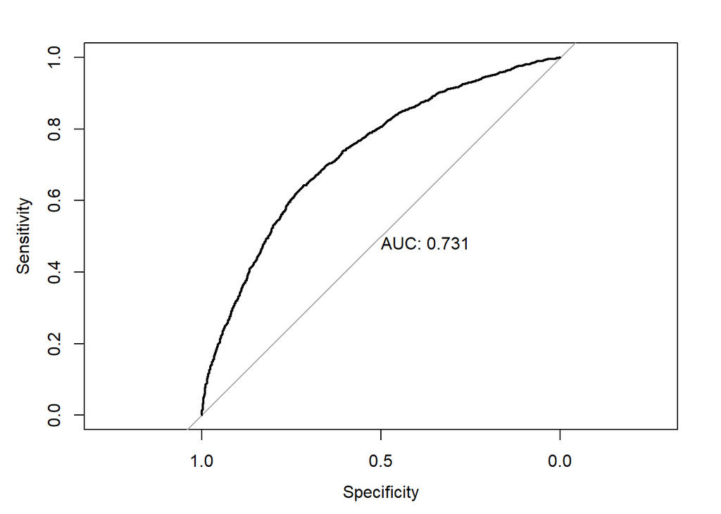

```r
test_roc = roc(test$Y ~ log_reg_prob1$"1", plot = TRUE, print.auc = TRUE)
```

## Linear Discriminant Analysis

With the removed variables

```r
lda.fit=lda(Y~.,data = train)
lda.fit
```

```
## Call:
## lda(Y ~ ., data = train)
##
## Prior probabilities of groups:
##         0         1
## 0.4315802 0.5684198
##
## Group means:
##   destinationNo Urgent Place destinationWork passangerFriends passangerKids
## 0                  0.4209378       0.2870774        0.1984733    0.08969466
## 1                  0.5549576       0.2196233        0.3044918    0.07120679
##   passangerPartner weatherSnowy weatherSunny temperature55 temperature80
## 0       0.08069793   0.13331516    0.7489095     0.3290622     0.4738277
## 1       0.09314842   0.09232043    0.8298489     0.2862761     0.5435728
##   couponCarry out & Take away couponCoffee House couponRestaurant(<20)
## 0                   0.1090513          0.3710469             0.1496728
## 1                   0.2411509          0.2777893             0.2769613
##   couponRestaurant(20-50) genderMale maritalStatusMarried partner
## 0              0.15130862  0.4612868                    0.4201200
## 1              0.09169944  0.5056924                    0.3877044
##   maritalStatusSingle maritalStatusUnmarried partner maritalStatusWidowed
## 0           0.3454198                      0.1761178          0.015267176
## 1           0.3930863                      0.1718071          0.008693852
##   educationBachelors degree educationGraduate degree
## 0                 0.3546892                0.1559433
## 1                 0.3361623                0.1324777
##   educationHigh School Graduate educationSome college - no degree
## 0                    0.06733915                         0.3241549
## 1                    0.07555372                         0.3595529
##   educationSome High School     Bar4~8     Bargt8  Barless1  Barnever
## 0               0.005179935 0.07142857 0.02753544 0.2827154 0.4443839
## 1               0.009107845 0.09480439 0.02939350 0.2829642 0.3781826
##   CoffeeHouse4~8 CoffeeHousegt8 CoffeeHouseless1 CoffeeHousenever CarryAway4~8
## 0      0.1183206     0.08342421        0.2884406        0.3007088    0.3353326
## 1      0.1577313     0.09045746        0.2653695        0.1891948    0.3498241
##   CarryAwaygt8 CarryAwayless1 CarryAwaynever RestaurantLessThan204~8
## 0    0.1297710      0.1679389    0.012540894               0.2715376
## 1    0.1268888      0.1312358    0.009107845               0.2951770
##   RestaurantLessThan20gt8 RestaurantLessThan20less1 RestaurantLessThan20never
## 0              0.09378408                 0.1780262                0.01826609
```

[output cut: 61 more lines]

```
## Restaurant20To504~8                  0.0893680059
## Restaurant20To50gt8                  0.1580131439
## Restaurant20To50less1               -0.2250586837
## Restaurant20To50never               -0.3171728982
## toCoupon_GEQ15min1                  -0.1108927523
## direction_same1                      0.5673085145
## age_weightage                       -0.0197719086
## occupation_classOthers               0.2394591887
## occupation_classProfessionals        0.0911343108
## occupation_classRetired             -0.0222752607
## occupation_classService and sales    0.1062711766
## occupation_classStudent             -0.0128815918
## occupation_classTechnicians and pro  0.2864814638
## occupation_classUnemployed          -0.0003169889
## expiration_weightage                 0.0401591282
```

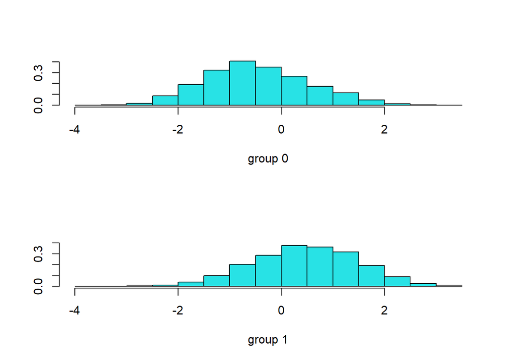

```r
plot(lda.fit)
```

```r
lda.pred=predict(lda.fit,test)$class
table(lda.pred,test$Y)
```

```
##
## lda.pred    0    1
##        0 1021  552
##        1  785 1827
```

```r
mean(lda.pred==test$Y)
```

```
## [1] 0.6805257
```

LDA predicts more False Positives as well

## Association Rules

We analyse association between Y and the ‘direction_same’, which is the significant variable

```r
assoc <- xtabs(~Y+direction_same, data=cleaned_data)
assoc
```

```
##    direction_same
## Y      0    1
##   0 4336 1138
##   1 5624 1586
```

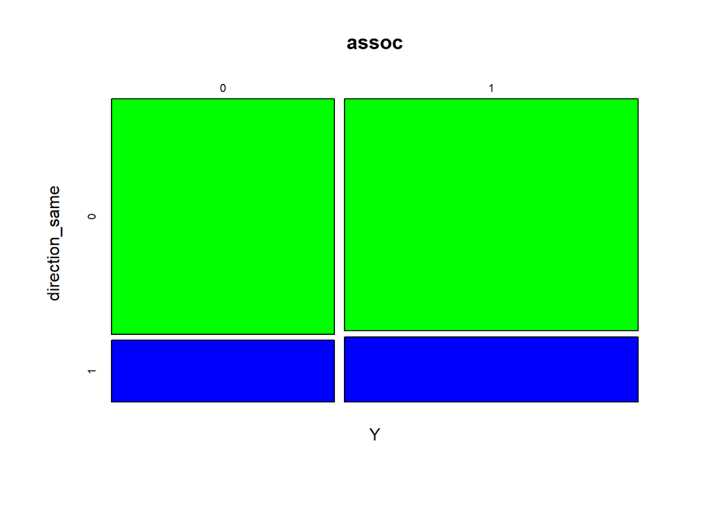

```r
plot(assoc, col=c("green","blue"))
```

**Testing significance**

```r
Test <- chisq.test(assoc, correct=FALSE)
Test
```

```
##
##  Pearson's Chi-squared test
##
## data:  assoc
## X-squared = 2.6927, df = 1, p-value = 0.1008
```

Chi2 is 2.7, relation between the variables is not significant (p-value> 0.05). We accept H0 about independence between the variables, there is no association.

```r
riskratio.wald(table(cleaned_data$direction_same,cleaned_data$Y))
```

```
## $data
##
##            0    1 Total
##   0     4336 5624  9960
##   1     1138 1586  2724
##   Total 5474 7210 12684
##
## $measure
##    risk ratio with 95% C.I.
##     estimate     lower    upper
##   0 1.000000        NA       NA
##   1 1.031122 0.9944796 1.069115
##
## $p.value
##    two-sided
##     midp.exact fisher.exact chi.square
##   0         NA           NA         NA
##   1  0.1006766    0.1016639  0.1008069
##
## $correction
## [1] FALSE
##
## attr(,"method")
## [1] "Unconditional MLE & normal approximation (Wald) CI"
```

```r
oddsratio.wald(table(cleaned_data$direction_same,cleaned_data$Y))
```

```
## $data
##
##            0    1 Total
##   0     4336 5624  9960
##   1     1138 1586  2724
##   Total 5474 7210 12684
##
## $measure
##    odds ratio with 95% C.I.
##     estimate     lower    upper
##   0 1.000000        NA       NA
##   1 1.074496 0.9861195 1.170793
##
## $p.value
##    two-sided
##     midp.exact fisher.exact chi.square
##   0         NA           NA         NA
##   1  0.1006766    0.1016639  0.1008069
##
## $correction
## [1] FALSE
##
## attr(,"method")
## [1] "Unconditional MLE & normal approximation (Wald) CI"
```

Confidence interval includes 1 - accept H0 about independence.

Odds: odds under direction same/ odds under direction opp = 1.07

```r
lr_fit <- glm(Y ~ direction_same, data = cleaned_data,
              family=binomial(link='logit'))
summary(lr_fit)
```

```
##
## Call:
## glm(formula = Y ~ direction_same, family = binomial(link = "logit"),
##     data = cleaned_data)
##
## Deviance Residuals:
##    Min      1Q  Median      3Q     Max
## -1.321  -1.290   1.040   1.069   1.069
##
## Coefficients:
##                 Estimate Std. Error z value Pr(>|z|)
## (Intercept)      0.26009    0.02021  12.870   <2e-16 ***
## direction_same1  0.07185    0.04379   1.641    0.101
## ---
## Signif. codes:  0 '***' 0.001 '**' 0.01 '*' 0.05 '.' 0.1 ' ' 1
##
## (Dispersion parameter for binomial family taken to be 1)
##
##     Null deviance: 17345  on 12683  degrees of freedom
## Residual deviance: 17343  on 12682  degrees of freedom
## AIC: 17347
##
## Number of Fisher Scoring iterations: 4
```

```r
exp(cbind(OR = coef(lr_fit), confint(lr_fit)))
```

```
##                       OR     2.5 %   97.5 %
## (Intercept)     1.297048 1.2467161 1.349503
## direction_same1 1.074496 0.9862293 1.170939
```

Direction is not a factor.

## KNN model

Uploading a dataset with dummies that are all numeric

Algorithms which use distance based methods require all variables to be numeric

```r
coupon_data_encoded  <- read.csv("https://raw.githubusercontent.com/rijinbaby/Statistical-Learning/main/cleaned_data_encoded.csv")
```

```r
##the normalization function is created
nor <-function(x) { (x -min(x))/(max(x)-min(x))   }
coupon_data_encoded[,c("age_weightage","expiration_weightage","income_weightage")] <-
  as.data.frame(lapply(coupon_data_encoded[,c("age_weightage","expiration_weightage","income_weightage")],nor))
```

```r
#train/test split

set.seed(123)
split_train_test  <- createDataPartition(coupon_data_encoded$Y, p = .67,
                                  list = FALSE,
                                  times = 1)

train <- coupon_data_encoded[ split_train_test,]
test  <- coupon_data_encoded[-split_train_test,]

train_label <- train$Y
test_label <- test$Y

test$Y <- NULL
train$Y <- NULL
```

**KNN confusion matrix and accuracy for K=10**

```r
##run knn function

model_knn <- knn(train = train, test = test ,cl=train_label,k=10)

##create confusion matrix
tab <- table(model_knn,test_label)
tab
```

```
##          test_label
## model_knn    0    1
##         0 1045  503
##         1  802 1835
```

```r
accuracy <- function(x){sum(diag(x)/(sum(rowSums(x)))) * 100}
accuracy(tab)
```

```
## [1] 68.8172
```

```r
CrossTable(x=model_knn, y=test_label, prop.chisq=FALSE)
```

```
##
##
##    Cell Contents
## |-------------------------|
## |                       N |
## |           N / Row Total |
## |           N / Col Total |
## |         N / Table Total |
## |-------------------------|
##
##
## Total Observations in Table:  4185
##
##
##              | test_label
##    model_knn |         0 |         1 | Row Total |
## -------------|-----------|-----------|-----------|
##            0 |      1045 |       503 |      1548 |
##              |     0.675 |     0.325 |     0.370 |
##              |     0.566 |     0.215 |           |
##              |     0.250 |     0.120 |           |
## -------------|-----------|-----------|-----------|
##            1 |       802 |      1835 |      2637 |
##              |     0.304 |     0.696 |     0.630 |
##              |     0.434 |     0.785 |           |
##              |     0.192 |     0.438 |           |
## -------------|-----------|-----------|-----------|
## Column Total |      1847 |      2338 |      4185 |
##              |     0.441 |     0.559 |           |
## -------------|-----------|-----------|-----------|
##
##
```

Check training and test errors for different values of K

```r
#loop for different  0<K<21
k <- 1
accuracy_scores_test <- c()
accuracy_scores_train <- c()
k_values <- c()
while (k < 16) {
  k_values <- c(k_values, k)
  test_knn <- knn(train = train, test = test ,cl=train_label,k=k)
  train_knn <- knn(train = train, test = train ,cl=train_label,k=k)
  tab_test <- table(test_knn,test_label)
  tab_train <- table(train_knn,train_label)
  accuracy_scores_test <- c(accuracy_scores_test, accuracy(tab_test))
  accuracy_scores_train <- c(accuracy_scores_train, accuracy(tab_train))
  k = k+1
}

acc = cbind(data.frame(k_values), data.frame(accuracy_scores_test), data.frame(accuracy_scores_train))
acc
```

```
##    k_values accuracy_scores_test accuracy_scores_train
## 1         1             63.67981              99.84704
## 2         2             63.29749              83.13919
## 3         3             65.85424              82.97447
## 4         4             65.87814              79.10342
## 5         5             67.19235              79.23285
## 6         6             66.47551              77.76209
## 7         7             67.69415              78.10331
## 8         8             68.41099              77.71503
## 9         9             68.67384              77.44441
## 10       10             68.26762              77.12672
## 11       11             68.64994              76.99729
## 12       12             68.14815              76.98553
## 13       13             68.79331              76.59725
## 14       14             69.48626              76.36192
## 15       15             69.48626              76.46782
```

Plotting accuracy for training (blue) and test sets (red)

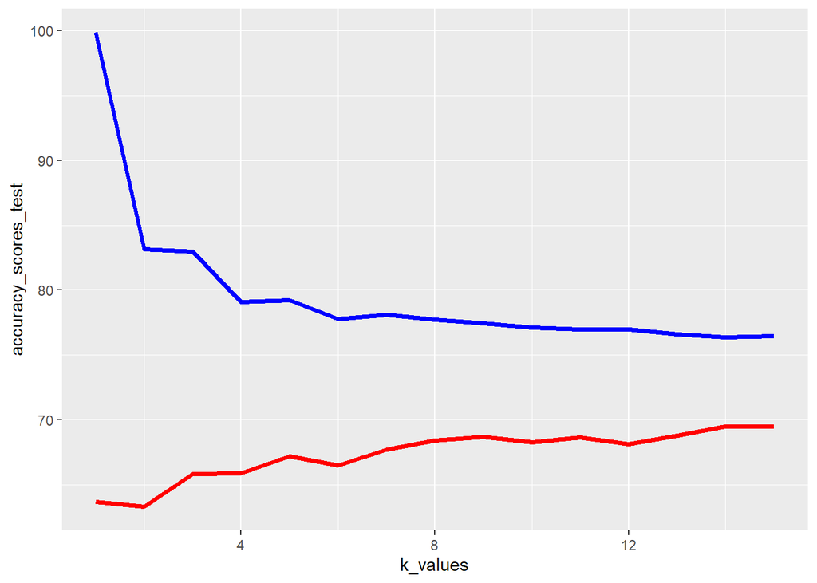

```r
ggplot(acc, aes(x=k_values)) +
  geom_line(aes(y = accuracy_scores_test), color = "red", size=1.3) +
  geom_line(aes(y = accuracy_scores_train), color="blue", size=1.3)
```

```r
  # cleaned_data$age <- NULL; cleaned_data$income <- NULL; cleaned_data$occupation<- NULL; cleaned_data$expiration <- NULL
  #
  # # library(caret)
  # # dummy <- dummyVars(" ~ .", data=cleaned_data)
  # # coupon_data_encoded <- data.frame(predict(dummy, newdata = cleaned_data))
  #
  # encoded <- fastDummies::dummy_cols(cleaned_data, remove_first_dummy = TRUE)
  #
  # coupon_data_encoded <- encoded[ , ((!(colnames(encoded) %in% colnames(cleaned_data)))
  #                                    | (colnames(encoded) %in% c("Y","age_weightage","income_weightage","expiration_weightage")))]
```

```r
# newdata_pca <- prcomp(coupon_data_encoded[,-(which(colnames(coupon_data_encoded)=="Y"))], center = TRUE,scale. = TRUE)
# summary(newdata_pca) # need to select PC32 for a cumulative variance of > 80
# newdata_pca$sdev
# View(newdata_pca$rotation)
```